# chapter-2-introduction-to-stringr

Xiaotian Sun

14/03/2020

## 2. Introduction to Stringr

##### 2.1 Introducing stringr (video)

##### 2.2 Putting strings together with stringr

For your first `stringr` function, we’ll look at `str_c()`, the `c` is short for concatenate, a function that works like `paste()`. It takes vectors of strings as input along with `sep` and `collapse` arguments.

There are two key ways `str_c()` differs from `paste()`. First, the default separator is an empty string, `sep = ""`, as opposed to a space, so it’s more like `paste0()`. This is an example of a `stringr` function, performing a similar operation to a `base` function, but using a default that is more likely to be what you want. Remember in your pizza order, you had to set `sep = ""` multiple times.

The second way `str_c()` differs to `paste()` is in its handling of missing values. `paste()` turns missing values into the string `"NA"`, whereas `str_c()` propagates missing values. That means combining any strings with a missing value will result in another missing value.

Let’s explore this difference using your pizza order from the previous chapter.

*Instruction:*

We’ve set up a new `my_toppings` vector that has a few missing values and taken the first step of creating our order.

- Print `my_toppings_and` to see what `paste()` did with the missing values.
- Repeat the `paste()` statement but instead use `str_c()`. You can save some typing by leaving off `sep = ""` since that is the default. Call this string `my_toppings_str`.
- Print `my_toppings_str` to see what `str_c()` does with the missing values.
- Take the next step in our order, by using `paste()` on `my_toppings_and` with `collapse = ", "`.
- Take the next step in our order, by using `str_c()` on my_toppings_str with `collapse = ", "`. See the difference: just one `NA` will make our entire result `NA`.

```r
library(stringr)

my_toppings <- c("cheese", NA, NA)
my_toppings_and <- paste(c("", "", "and "), my_toppings, sep = "")

# Print my_toppings_and
my_toppings_and
```

```
## [1] "cheese" "NA"     "and NA"
```

```r
# Use str_c() instead of paste(): my_toppings_str
my_toppings_str <- str_c(c("", "", "and "), my_toppings, sep = "")

# Print my_toppings_str
my_toppings_str
```

```
## [1] "cheese" NA       NA
```

```r
# paste() my_toppings_and with collapse = ", "
paste(my_toppings_and, collapse = ", ")
```

```
## [1] "cheese, NA, and NA"
```

```r
# str_c() my_toppings_str with collapse = ", "
str_c(my_toppings_str, collapse = ", ")
```

```
## [1] NA
```

##### 2.3 String length

Our next `stringr` function is `str_length()`. `str_length()` takes a vector of strings as input and returns the number of characters in each string. For example, try finding the number of characters in Batman’s name:

> str_length(c(“Bruce”, “Wayne”))

This is very similar to the `base` function `nchar()` but you’ll see in the exercises `str_length()` handles factors in an intuitive way, whereas `nchar()` will just return an error.

Historically, `nchar()` was even worse, rather than returning an error if you passed it a factor, it would return the number of characters in the numeric encoding of the factor. Thankfully this behavior has been fixed, but it was one of the original motivations behind `str_length()`.

Take your first look at `babynames` by asking if girls’ names are longer than boys’ names.

*Instruction:*

We’ve pulled out just the names from 2014, and created the vectors `boy_names` and `girl_names` for you. (If you want to learn about the `filter()` function, take the `Data Manipulation in R with dplyr` course!).

- Take a look at the `boy_names` vector, it’s long, so use `head()` to see the first few elements.
- Use `str_length()` on `boy_names` to find the length of each name and save the result to `boy_length.`
- Take a look at the lengths. Again, use `head()`. Can you see the correspondence with `boy_names`?
- Find the length of all the girls’ names. Call this `girl_length`.
- Find the difference in mean length between boys’ and girls’ names by subtracting the mean length of boys’ names from that of girls’ names.
- Confirm `str_length()` works on factors, by calling it on `factor(boy_names)`. Again, you’ll want to just look at the `head()`.

```r
library(stringr)
library(babynames)
library(dplyr)
# Extracting vectors for boys' and girls' names
babynames_2014 <- filter(babynames, year == 2014)
boy_names <- filter(babynames_2014, sex == "M")$name
girl_names <- filter(babynames_2014, sex == "F")$name

# Take a look at a few boy_names
head(boy_names)
```

```
## [1] "Noah"    "Liam"    "Mason"   "Jacob"   "William" "Ethan"
```

```r
# Find the length of all boy_names
boy_length <- str_length(boy_names)

# Take a look at a few lengths
head(boy_length)
```

```
## [1] 4 4 5 5 7 5
```

```r
# Find the length of all girl_names
girl_length <- str_length(girl_names)

# Find the difference in mean length
mean(girl_length) - mean(boy_length)
```

```
## [1] 0.3374758
```

```r
# Confirm str_length() works with factors
head(str_length(factor(boy_names)))
```

```
## [1] 4 4 5 5 7 5
```

##### 2.4 Extracting substrings

The `str_sub()` function in `stringr` extracts parts of strings based on their location. As with all `stringr` functions, the first argument, `string`, is a vector of strings. The arguments `start` and `end` specify the boundaries of the piece to extract in characters.

For example, `str_sub(x, 1, 4)` asks for the substring starting at the first character, up to the fourth character, or in other words the first four characters. Try it with my Batman’s name:

> str_sub(c(“Bruce”, “Wayne”), 1, 4)

Both `start` and `end` can be negative integers, in which case, they count from the end of the string. For example, `str_sub(x, -4, -1)`, asks for the substring starting at the fourth character from the end, up to the first character from the end, i.e. the last four characters. Again, try it with Batman:

> str_sub(c(“Bruce”, “Wayne”), -4, -1)

To practice, you’ll use `str_sub()` to look at popular first and last letters for names.

*Instruction:*

We’ve set up the same `boy_names` and `girl_names` vectors from the last exercise in your workspace.

- Use `str_sub()` to extract the first letter of each name in `boy_names`. Save this to `boy_first_letter`.
- Use `table()` on `boy_first_letter` to count up how many names start with each letter. Can you see which is most popular?
- Repeat these steps, but now look at the last letter for boys’ names.
- Again repeat, but now look at the first letter for girls’ names.
- Finally, look at the last letter for girls’ names.

```r
# Extract first letter from boy_names
boy_first_letter <- str_sub(boy_names, 1, 1)

# Tabulate occurrences of boy_first_letter
table(boy_first_letter)
```

```
## boy_first_letter
##    A    B    C    D    E    F    G    H    I    J    K    L    M    N    O
## 1454  651  770  998  549  185  334  403  235 1390 1291  537  914  424  207
##    P    Q    R    S    T    U    V    W    X    Y    Z
##  230   56  778  806  771   43  160  174   56  252  379
```

```r
# Extract the last letter in boy_names, then tabulate
boy_last_letter <- str_sub(boy_names, -1,-1)
table(boy_last_letter)
```

```
## boy_last_letter
##    a    b    c    d    e    f    g    h    i    j    k    l    m    n    o
##  421  104   92  436 1148   66   82  583  705   57  349  945  389 4672  730
##    p    q    r    s    t    u    v    w    x    y    z
##   32   19 1011  826  292   81   71   34   86  697  119
```

```r
# Extract the first letter in girl_names, then tabulate
girl_first_letter <- str_sub(girl_names, 1, 1)
table(girl_first_letter)
```

```
## girl_first_letter
##    A    B    C    D    E    F    G    H    I    J    K    L    M    N    O
## 3101  699  946  810  933  209  345  469  373 1430 1694 1122 1746  752  143
##    P    Q    R    S    T    U    V    W    X    Y    Z
##  303   38  831 1369  683   28  214   85   62  294  502
```

```r
# Extract the last letter in girl_names, then tabulate
girl_last_letter <- str_sub(girl_names, -1, -1)
table(girl_last_letter)
```

```
## girl_last_letter
##    a    b    c    d    e    f    g    h    i    j    k    l    m    n    o
## 6632   20   13   81 3114    8   21 1942 1581   12   31  450  115 2608  105
##    p    q    r    s    t    u    v    w    x    y    z
##    3    2  291  326  208   59    6   17   50 1435   51
```

##### 2.5 Hunting for matches (video)

##### 2.6 Detecting matches

`str_detect()` is used to answer the question: Does the string contain the pattern? It returns a logical vector of the same length as that of the input vector `string`, with `TRUE` for elements that contain the pattern and `FALSE` otherwise.

Let’s take a look at a simple example where you have a vector of strings that represent pizza orders:

> pizzas <- c(“cheese”, “pepperoni”, “sausage and green peppers”)

You can ask which orders contain the pattern `"pepper"`, with

> str_detect(pizzas, pattern = fixed(“pepper”))

Try it out! You should get `FALSE TRUE TRUE`. Notice how both pepperoni and green peppers contain the pattern of interest.

The output from `str_detect()` can be used to count the number of occurrences, or to subset out the strings that contain the pattern. You’ll practice both to find the boys’ names that contain `"zz"`.

*Instruction:*

- Use `str_detect()` to find which `boy_names` contain `"zz"`. Save the result to `contains_zz`.
- Examine the structure of `contains_zz` with `str()`. It should be a logical vector the same length as `boy_names`.
- To find out how many names in `boy_names` contain `"zz"`, use `sum()` on `contains_zz`. Recall summing a logical vector counts how many are `TRUE`.
- To find the names in `boy_names` that contain `"zz"`, subset `boy_names` using `[` and `contains_zz`.
- We’ve also included `boy_df` in your workspace, a data frame that corresponds to the boys’ names in 2014. Subset the rows of `boy_df` using `contains_zz`.

```r
# Look for pattern "zz" in boy_names
contains_zz <- str_detect(boy_names, pattern = fixed("zz"))

# Examine str() of contains_zz
str(contains_zz)
```

```
##  logi [1:14047] FALSE FALSE FALSE FALSE FALSE FALSE ...
```

```r
# How many names contain "zz"?
sum(contains_zz)
```

```
## [1] 16
```

```r
# Which names contain "zz"?
boy_names[contains_zz]
```

```
##  [1] "Uzziah"    "Ozzie"     "Ozzy"      "Jazz"      "Uzziel"
##  [6] "Chazz"     "Izzy"      "Azzam"     "Izzac"     "Izzak"
## [11] "Fabrizzio" "Jazziel"   "Azzan"     "Izzaiah"   "Muizz"
## [16] "Yazziel"
```

```r
# Which rows in boy_df have names that contain "zz"?
boy_df <- filter(babynames_2014, sex == "M")
boy_df[contains_zz,]
```

```
## # A tibble: 16 x 5
##     year sex   name          n       prop
##    <dbl> <chr> <chr>     <int>      <dbl>
##  1  2014 M     Uzziah       67 0.0000328
##  2  2014 M     Ozzie        62 0.0000303
##  3  2014 M     Ozzy         57 0.0000279
##  4  2014 M     Jazz         21 0.0000103
##  5  2014 M     Uzziel       21 0.0000103
##  6  2014 M     Chazz        17 0.00000832
##  7  2014 M     Izzy         16 0.00000783
##  8  2014 M     Azzam        14 0.00000685
##  9  2014 M     Izzac        13 0.00000636
## 10  2014 M     Izzak         8 0.00000391
## 11  2014 M     Fabrizzio     7 0.00000342
## 12  2014 M     Jazziel       6 0.00000293
## 13  2014 M     Azzan         5 0.00000245
## 14  2014 M     Izzaiah       5 0.00000245
## 15  2014 M     Muizz         5 0.00000245
## 16  2014 M     Yazziel       5 0.00000245
```

##### 2.7 Subsetting strings based on match

Since detecting strings with a pattern and then subsetting out those strings is such a common operation, `stringr` provides a function `str_subset()` that does that in one step.

For example, let’s repeat our search for `"pepper"` in our `pizzas` using `str_subset()`:

> pizzas <- c(“cheese”, “pepperoni”, “sausage and green peppers”) str_subset(pizzas, pattern = fixed(“pepper”))

We get a new vector of strings, but it only contains those original strings that contained the pattern.

`str_subset()` can be easily confused with `str_extract()`. `str_extract()` returns a vector of the same length as that of the input vector, but with only the parts of the strings that matched the pattern. This won’t be very interesting until we know about regular expressions, so we’ll talk more about this in Chapter 3.

For now, you’ll repeat part of the last exercise using `str_subset()` and then find a few other interesting names.

*Instruction:*

- Find the `boy_names` that contain `"zz"`, using `str_subset()`.
- Find the `girl_names` that contain `"zz"`.
- Find the `girl_names` that contain `"U"` and save into `starts_U`. Since the pattern matching is case sensitive, this will only be names that start with `"U"`.
- Feed `starts_U` into another `str_subset()` that looks for `"z"`. Combining multiple `str_subset()` calls is a way to find more complicated patterns.

```r
# Find boy_names that contain "zz"
str_subset(boy_names, pattern = fixed("zz"))
```

```
##  [1] "Uzziah"    "Ozzie"     "Ozzy"      "Jazz"      "Uzziel"
##  [6] "Chazz"     "Izzy"      "Azzam"     "Izzac"     "Izzak"
## [11] "Fabrizzio" "Jazziel"   "Azzan"     "Izzaiah"   "Muizz"
## [16] "Yazziel"
```

```r
# Find girl_names that contain "zz"
str_subset(girl_names, pattern = fixed("zz"))
```

```
##  [1] "Izzabella"  "Jazzlyn"    "Jazzlynn"   "Lizzie"     "Izzy"
##  [6] "Lizzy"      "Mazzy"      "Izzabelle"  "Jazzmine"   "Jazzmyn"
## [11] "Jazzelle"   "Jazzmin"    "Izzah"      "Jazzalyn"   "Jazzmyne"
## [16] "Izzabell"   "Jazz"       "Mazzie"     "Alyzza"     "Izza"
## [21] "Izzie"      "Jazzlene"   "Lizzeth"    "Jazzalynn"  "Jazzy"
## [26] "Alizzon"    "Elizzabeth" "Jazzilyn"   "Jazzlynne"  "Jizzelle"
## [31] "Izzabel"    "Izzabellah" "Izzibella"  "Jazzabella" "Jazzabelle"
## [36] "Jazzel"     "Jazzie"     "Jazzlin"    "Jazzlyne"   "Aizza"
## [41] "Brizza"     "Ezzah"      "Fizza"      "Izzybella"  "Rozzlyn"
```

```r
# Find girl_names that contain "U"
starts_U <- str_subset(girl_names, pattern = fixed("U"))
starts_U
```

```
##  [1] "Unique"  "Uma"     "Unknown" "Una"     "Uriah"   "Ursula"  "Unity"
##  [8] "Umaiza"  "Urvi"    "Ulyana"  "Ula"     "Udy"     "Urwa"    "Ulani"
## [15] "Umaima"  "Umme"    "Ugochi"  "Ulyssa"  "Umika"   "Uriyah"  "Ubah"
## [22] "Umaira"  "Umi"     "Ume"     "Urenna"  "Uriel"   "Urijah"  "Uyen"
```

```r
# Find girl_names that contain "U" and "z"
str_subset(starts_U, pattern = "z")
```

```
## [1] "Umaiza"
```

##### 2.8 Counting matches

Another `stringr` function that takes a vector of strings and a pattern is `str_count()`. `str_count()` answers the question “How many times does the pattern occur in each string?”. It always returns an integer vector of the same length as that of the input vector.

If you count the occurrences of `"pepper"` in your `pizzas`, you’ll find no occurrences in the first, and one each in the second and third,

> pizzas <- c(“cheese”, “pepperoni”, “sausage and green peppers”) str_count(pizzas, pattern = fixed(“pepper”))

Perhaps a little more interesting is to count how many `"e"`s occur in each order

> str_count(pizzas, pattern = fixed(“e”))

You’ll use `str_count()` to find some names with lots of repeated letters.

*Instruction:*

- Count the number of `"a"` in each `girl_names`, store in `number_as`.
- Count the number of `"A"` in each `girl_names`, store in `number_As`.
- Create histograms, use the `hist()` function, of `number_as` and `number_As`. Why is `number_As` only zero or one?
- Add together `number_as` and `number_As` to get `total_as`.
- Subset `girl_names` to only those names where `total_as > 4`.

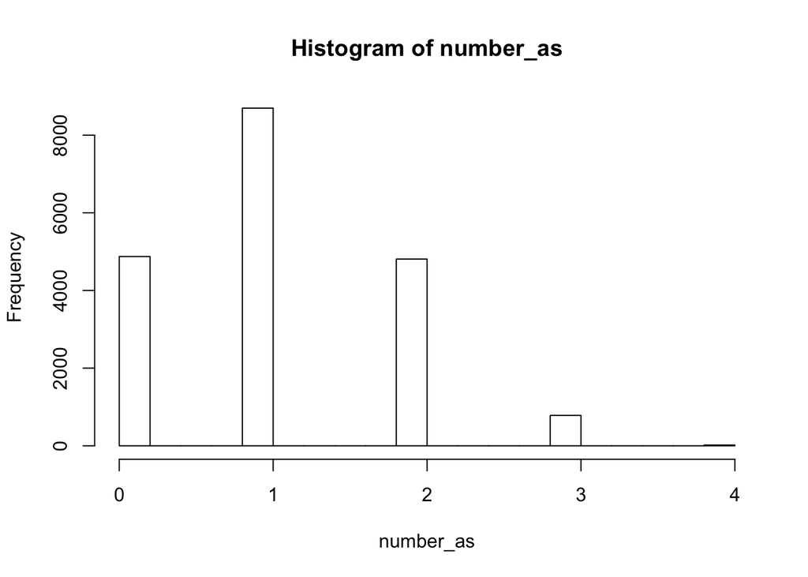

```r
# Count occurrences of "a" in girl_names
number_as <- str_count(girl_names, pattern = fixed("a"))

# Count occurrences of "A" in girl_names
number_As <- str_count(girl_names, pattern = fixed("A"))

# Histograms of number_as and number_As
hist(number_as)
```

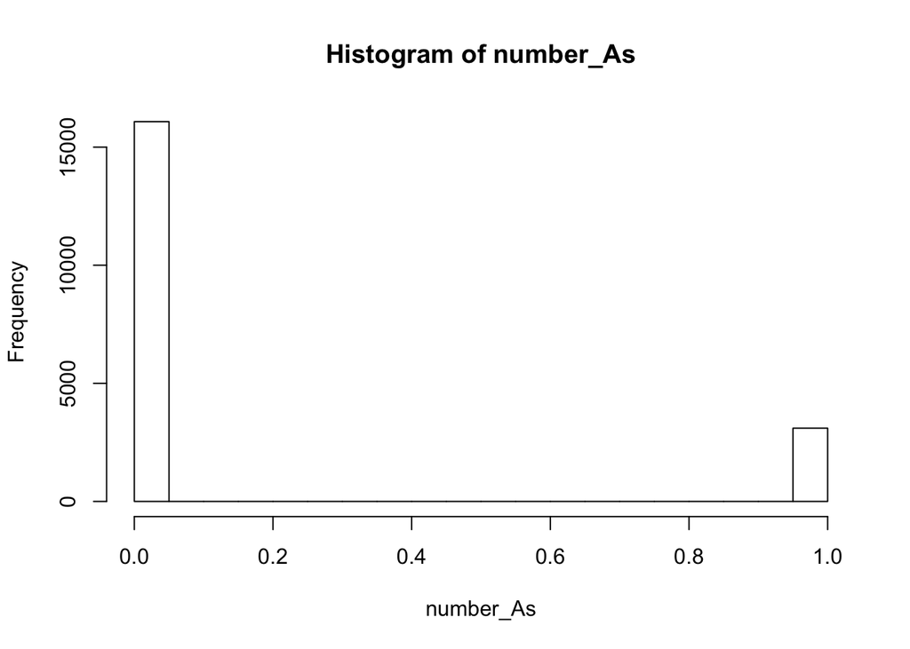

```r
hist(number_As)
```

```r
# Find total "a" + "A"
total_as <- number_As + number_as

# girl_names with more than 4 a's
girl_names[total_as > 4]
```

```
## [1] "Aaradhana"
```

##### 2.9 Splitting strings (video)

##### 2.10 Parsing strings into variables

A common use for `str_split()` is to pull apart raw string data into more useful variables. In this exercise you’ll start by pulling apart a date range, something like `"23.01.2017 - 29.01.2017"`, into separate variables for the start of the range, `"23.01.2017"`, and the end of the range, `"29.01.2017"`.

Remember, if the `simplify` argument is `FALSE` (the default) you’ll get back a list of the same length as that of the input vector. More commonly, you’ll want to pull out the first piece (or second piece etc.) from every element, which is easier if you specify `simplify = TRUE` and get a matrix as output. You’ll explore both of these output types in this exercise.

*Instruction 1:*

Split `date_ranges` using `" - "` as a pattern, assign this to `split_dates`. Don’t forget to wrap the pattern in `fixed()`. Print `split_dates`. The result is a list with two elements, since `date_ranges` was a vector of length two.

```r
# Some date data
date_ranges <- c("23.01.2017 - 29.01.2017", "30.01.2017 - 06.02.2017")

# Split dates using " - "
split_dates <- str_split(date_ranges, pattern = fixed(" - "))
split_dates
```

```
## [[1]]
## [1] "23.01.2017" "29.01.2017"
##
## [[2]]
## [1] "30.01.2017" "06.02.2017"
```

*Instruction 2:*

Now, split `date_ranges` again, but specify `simplify = TRUE` and `n = 2`. Print the result to see the difference. Now we get a matrix back, where each row corresponds to an element of `date_ranges`.

```r
# Some date data
date_ranges <- c("23.01.2017 - 29.01.2017", "30.01.2017 - 06.02.2017")

# Split dates with n and simplify specified
split_dates_n <- str_split(date_ranges, pattern = fixed(" - "), simplify = TRUE, n = 2)
split_dates_n
```

```
##      [,1]         [,2]
## [1,] "23.01.2017" "29.01.2017"
## [2,] "30.01.2017" "06.02.2017"
```

*Instruction 3:*

- Pull out the first column of `split_dates_n` into `start_dates`.
- Split `start_dates` into its day, month and year components. You are aiming for a three column matrix as the result.

```r
# From previous step
date_ranges <- c("23.01.2017 - 29.01.2017", "30.01.2017 - 06.02.2017")
split_dates_n <- str_split(date_ranges, fixed(" - "), n = 2, simplify = TRUE)

# Subset split_dates_n into start_dates and end_dates
start_dates <- split_dates_n[, 1]
end_dates <- split_dates_n[, 2]

# Split start_dates into day, month and year pieces
str_split(start_dates, pattern = fixed("."), simplify = TRUE)
```

```
##      [,1] [,2] [,3]
## [1,] "23" "01" "2017"
## [2,] "30" "01" "2017"
```

*Instruction 4:*

Now you’re on your own. We’ve provided the `both_names` vector, listing a couple of famous statisticians. Your job is to pull out the first names and last names into separate vectors. You’ll need to use an intermediate variable, `both_names_split`.

```r
both_names <- c("Box, George", "Cox, David")

# Split both_names into first_names and last_names
both_names_split <- str_split(both_names, pattern = fixed(", "), simplify = TRUE)

# Get first names
first_names <- both_names_split[, 2]

# Get last names
last_names <- both_names_split[, 1]
```

##### 2.11 Some simple text statistics

Generally, specifying `simplify = TRUE` will give you output that is easier to work with, but you’ll always get `n` pieces (even if some are empty, `""`).

Sometimes, you want to know how many pieces a string can be split into, or you want to do something with every piece before moving to a simpler structure. This is a situation where you don’t want to simplify and you’ll have to process the output with something like `lapply()`.

As an example, you’ll be performing some simple text statistics on your lines from Alice’s Adventures in Wonderland from Chapter 1. Your goal will be to calculate how many words are in each line, and the average length of words in each line.

To do these calculations, you’ll need to split the lines into words. One way to break a sentence into words is to split on an empty space `" "`. This is a little naive because, for example, it wouldn’t pick up words separated by a newline escape sequence like in `"two\nwords"`, but since this situation doesn’t occur in your lines, it will do.

*Instruction:*

We’ve put `lines` a vector with three strings, each corresponding to a line in your workspace.

- Split `lines` into words. Assign the resulting list to `words`.
- Use `lapply()` to apply `length()` to each element in words to count the number of `words` in each line.
- Use `lapply()` to apply `str_length()` to each element in `words`, to count the number of characters in each word. Assign this to `word_lengths`.
- Use `lapply()` to apply `mean()` to each element in `word_lengths`, to find the average word length in each line.

```r
# Split lines into words
words <- str_split(lines, pattern = fixed(" "))

# Number of words per line
lapply(words, length)
```

```
## [[1]]
## [1] 18
##
## [[2]]
## [1] 12
##
## [[3]]
## [1] 21
```

```r
# Number of characters in each word
word_lengths <- lapply(words, str_length)

# Average word length per line
lapply(word_lengths, mean)
```

```
## [[1]]
## [1] 3.888889
##
## [[2]]
## [1] 4.25
##
## [[3]]
## [1] 4.380952
```

##### 2.12 Replacing matches in strings (video)

##### 2.13 Replacing to tidy strings

You’ve seen one common strategy to pull variables out of strings is to split the string based on a pattern. Sometimes, it’s easier to just replace the parts you don’t want with an empty string `""`. This is also a common strategy to clean strings up, for example, to remove unwanted punctuation or white space.

In this exercise you’ll pull out some numbers by replacing the part of the string that isn’t a number, you’ll also play with the format of some phone numbers. Pay close attention to the difference between `str_replace()` and `str_replace_all()`.

*Instruction 1:*

- Keep the numeric part of `ids`, by replacing `"ID#: "` with an empty string `""`.
- Turn the ID strings to numbers using `as.numeric()`, assign the result to `id_ints`.

```r
# Some IDs
ids <- c("ID#: 192", "ID#: 118", "ID#: 001")

# Replace "ID#: " with ""
id_nums <- str_replace(ids, "ID#: ", "")

# Turn id_nums into numbers
id_ints <- as.numeric(id_nums)
```

*Instruction 2:*

- Use `str_replace()` on `phone_numbers` to replace the `"-"` with a space, `" "`. Take a close look at the output, are there still some `"-"`s?
- Repeat the previous task but now use `str_replace_all()`. Notice the difference, all the `"-"`s are replaced!
- Reformat the phone numbers to use dots instead of dashes, i.e. in the format `xxx.xxx.xxxx`.

```r
# Some (fake) phone numbers
phone_numbers <- c("510-555-0123", "541-555-0167")

# Use str_replace() to replace "-" with " "
str_replace(phone_numbers, "-", " ")
```

```
## [1] "510 555-0123" "541 555-0167"
```

```r
# Use str_replace_all() to replace "-" with " "
str_replace_all(phone_numbers, "-", " ")
```

```
## [1] "510 555 0123" "541 555 0167"
```

```r
# Turn phone numbers into the format xxx.xxx.xxxx
str_replace_all(phone_numbers, "-", ".")
```

```
## [1] "510.555.0123" "541.555.0167"
```

##### 2.14 Review

You’ve covered a lot of `stringr` functions in this chapter:

- `str_c()`
- `str_length()`
- `str_sub()`
- `str_detect()`
- `str_subset()`
- `str_count()`
- `str_split()`
- `str_replace()`

As a review we’ve got a few tasks for you to do with some DNA sequences. We’ve put three sequences, corresponding to three genes, from the genome of Yersinia pestis – the bacteria that causes bubonic plague – into the vector `genes`.

Each string represents a gene, each character a particular nucleotide: Adenine, Cytosine, Guanine or Thymine.

We aren’t going to tell you which function to use. It’s up to you to choose the right one and specify the needed arguments. Good luck!

*Instruction:*

- Find the number of nucleotides in each gene.
- Find the number of `A`’s that occur in each gene.
- Return the sequences that contain the sequence `"TTTTTT"`.
- Replace all the `A`s in the sequences with a `_`.

```r
# Find the number of nucleotides in each sequence
str_length(genes)
```

```
## [1] 441 462 993
```

```r
# Find the number of A's occur in each sequence
str_count(genes, pattern = fixed("A"))
```

```
## [1] 118 117 267
```

```r
# Return the sequences that contain "TTTTTT"
str_subset(genes, pattern = fixed("TTTTTT"))
```

```
## [1] "TTAAGGAACGATCGTACGCATGATAGGGTTTTGCAGTGATATTAGTGTCTCGGTTGACTG…"
```

```r
# Replace all the "A"s in the sequences with a "_"
str_replace_all(genes, pattern = fixed("A"), replacement = "_")
```

```
## [1] "TT_G_GT___TT__TCC__TCTTTG_CCC___TCTCTGCTGG_TCCTCTGGT_TTTC_TGTTGG_TG_CGTC__TTTCT__T_TTTC_CCC__CCGTTG_GC_CCTTGTGCG_TC__TTGTTG_TCC_GTTTT_TG_TTGC_CCGC_G___GTGTC_T_TTCTG_GCTGCCT___CC__CCGCCCC___GCGT_CTTGGG_T___TC_GGCTTTTGTTGTTCG_TCTGTTCT__T__TGGCTGC__GTT_TC_GGT_G_TCCCCGGC_CC_TG_GTGG_TGTC_CG_TT__C…
## [2] "TT__GG__CG_TCGT_CGC_TG_T_GGGTTTTGC_GTG_T_TT_GTGTCTCGGTTG_CTGG_TCTC_TC__T_GTCTGG_TTTTGTTG_T__GT_CCTGCTGC__TGC_TC__TGG_TTT_C_C_TC_CTTT__T___T_TGCTGT_GTGGCC_GTGGTGT__T_GGCCTC__CC_CTTCTTCT__GCTTTCC__TTTTTTC__GGCGG__GGGT__TCTTTGGC_CTTTTC__G_TT_TGCC__T___GC_GC___CGTCGT__CCC_GTTGTTTTGGGTT__CGTGT_C_…
## [3] "_TG______C__TTT_TCC_____C__C__C___TC_GCTTCGT____TC_TTCTTTTCCCGCC__TT_G_GC__C__CTTGGCTTG_TCG__GTCC_GGCTCCT_TTTTG_GCCGTGTGGGTG_TGG__CCC__G_T__CCTTTCTGGTTCTG_G___GCGGT_C_GGT____GTT__GTC_TTGCCGG_TTC__CTTTTG__GTTGT_C_TTC_TT_GCG__GTGG___CGT____CCTT_GGGCGTTTTG_TTTTGGTGCTG_CC__GGGGTGT_T_CCC_T_TG___G…
```

##### 2.15 Final challenges

You’ve mastered using `stringr` functions on their own, but by combining multiple operations together in sequence you can achieve quite complicated manipulations.

As the final exercise we want to expose you to the power of combining operations. You’ll complete two tasks:

1. You’ll turn a vector of full names, like `"Bruce Wayne"`, into abbreviated names like `"B. Wayne"`. This requires combining `str_split()`, `str_sub()` and `str_c()`.
2. You’ll compare how many boy names end in `"ee"` compared to girl names. This requires combining `str_sub()` with `str_detect()` along with the base function `table()`.

*Instruction 1:*

- Use `str_split()` to create a two column matrix with the first names in one column and the last names in the other. You’ll be manipulating the first name before combining it back with the second name in the next few steps.
- Create an abbreviation of the first name, `abb_first`, by extracting just the first character with `str_sub()`.
- Use `str_c()` to combine `abb_first` with `". "` and the last name column to finish the task!

```r
# Define some full names
names <- c("Diana Prince", "Clark Kent")

# Split into first and last names
names_split <- str_split(names, pattern = fixed(" "), simplify = TRUE)

# Extract the first letter in the first name
abb_first <- str_sub(names_split[, 1], 1, 1)

# Combine the first letter ". " and last name
str_c(abb_first,". ", names_split[,2])
```

```
## [1] "D. Prince" "C. Kent"
```

*Instruction 2:*

- Use `str_sub()` to extract the last two letters from `all_names`.
- Create a logical, `ends_in_ee` that identifies whether the `last_two_letters` are `ee`, using `str_detect()`.
- Subset the rows of `babynames_2014` using `ends_in_ee` and keep only the `sex` column. (Use the `$` notation to subset the `sex` column.)
- Apply `table()` to the result to complete the task!

```r
# Use all names in babynames_2014
all_names <- babynames_2014$name

# Get the last two letters of all_names
last_two_letters <- str_sub(all_names, -2, -1)

# Does the name end in "ee"?
ends_in_ee <- str_detect(last_two_letters, pattern = fixed("ee"))

# Extract rows and "sex" column
sex <- babynames_2014$sex[ends_in_ee]

# Display result as a table
table(sex)
```

```
## sex
##   F   M
## 572  84
```